# ST762-Asm04-PoissonBaye

Mave Danmei

2022-05-30

### Question 1 [15 marks]

Download vaso.data from Canvas — this contains the vasoconstriction dataset from lectures. The explanatory variables are Volume and Rate, and the response variable is Response.

#### Q 1 (a) [6 marks]

Write down the JAGS model to perform logistic regression on this data. Centre the explanatory variables, and use the probit link function.

```r
model="model

{
        # Priors

        beta0 ~ dunif(-1000, 1000)
        beta1 ~ dunif(-1000, 1000)
        beta2 ~ dunif(-1000, 1000)

        # Sampling distribution

        for(i in 1:length(Response))
        {
            probit(p[i])<-beta0 +beta1*(Volume[i])+beta2*(Rate[i])
            Response[i] ~ dbin(p[i],1)

        }

}
"

data=read.table("vaso.data",header=TRUE)

# vol.mean is mean of Volume, rat.mean is mean of Rate
vol.mean=mean(data$Volume)
rat.mean=mean(data$Rate)


data2=data.frame(Volume=data$Volume-vol.mean,Rate=data$Rate-rat.mean,Response=data$Response)



# Variables to monitor
variable_names = c("beta0", "beta1", "beta2")

# How many proper steps?
steps = 100000

# Thinning?
thin = 10

library("rjags")
# Create a JAGS model object
jm = jags.model(textConnection(model), data2)
# Do some MCMC
results = coda.samples(jm, variable_names, steps, thin=thin)

# Extract chains as data frame
results = as.data.frame(results[[1]])
```

#### Q1 (b)

2. [4 marks] Compute the posterior mean and a 95% credible interval for each of the coefficients in the model, and interpret the results in terms of what happens to the response as the explanatory variables change.

Q1(b) ANSWER:

beta0 increases, correspondingly the probability of vasoconstriction increases.

```r
# posterior mean for beta0
mean(results$beta0)
```

```
## [1] 0.2143897
```

```r
quantile(results$beta0,probs = c(0.025,0.975))
```

```
##       2.5%      97.5%
## -0.3244957  0.7764975
```

Q1 (b) ANSWER:

beta1 is positive, it means: the volume increases, would result in the probability of vasoconstriction increasing.(the probability of Response variable would increase. )

```r
# posterior mean for beta1
mean(results$beta1)
```

```
## [1] 2.337155
```

```r
quantile(results$beta1,probs = c(0.025,0.975))
```

```
##     2.5%    97.5%
## 1.101255 3.815831
```

Q1 (b) ANSWER:

beta2 is positive, it means : the Rate increases, would result in the increasing of the probability of vasoconstriction(the probability of Response variable would increase. )

```r
# posterior mean for beta2
mean(results$beta2)
```

```
## [1] 1.63592
```

```r
quantile(results$beta2,probs = c(0.025,0.975))
```

```
##      2.5%     97.5%
## 0.7792604 2.6842031
```

### Prediction

We will now cover how to use JAGS to make a prediction of a new data point. It involves adding a new variable to the JAGS model to specify the probability distribution of the new point, conditional on all the parameters (and, if necessary , conditional on the previous points–this would occur in time series modelling, for example). Almost always, the distribution assumed for the new data point should be the same as for the previous data points.

In regression models , you need to specify values for the explanatory variables for the new point, or it won’t work.

#### Q1 (c)

3. [5 marks] Suppose ten trials are going to be conducted with Volume=1.0 and Rate=2.0. Write JAGS code to predict r, the number of successes out of these ten trials. What is the most probable value of r and what is its probability?

```r
model="model

{
        # Priors

        beta0 ~ dunif(-1000, 1000)
        beta1 ~ dunif(-1000, 1000)
        beta2 ~ dunif(-1000, 1000)

        # Sampling distribution

        for(i in 1:length(Response))
        {
            probit(p[i])<-beta0 +beta1*Volume[i]+beta2*Rate[i]
            Response[i] ~ dbin(p[i],1)

        }

        probit(p_new)<-beta0 + beta1*1 + beta2*2
        Response_new ~ dbin(p_new,1)

}
"
# Variables to monitor
variable_names = c("beta0", "beta1", "beta2","Response_new")

# Create a JAGS model object
jm = jags.model(textConnection(model), data2)
results=coda.samples(jm,variable_names,steps, thin=thin)

results=as.data.frame(results[[1]])
```

The results look like a binomial distribution.

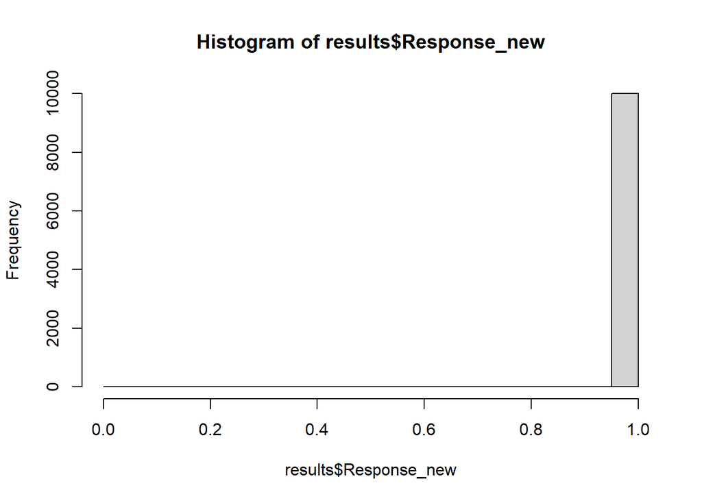

```r
hist(results$Response_new)
```

```r
# probit_p is probit(p) for Volume=1.0, Rate=2.0

probit_p=mean(results$beta0)+mean(results$beta1*1)+mean(results$beta2*2)
probit_p
```

```
## [1] 5.844681
```

```r
# 0.5337211
```

the probability for Volume=1, Rate=2 to catch vasoconstriction is: 1.

AS: pnorm (probability), since probit_p =qnorm(probability)

```r
pnorm(probit_p)
```

```
## [1] 1
```

pnorm(0.0846272)

[output not shown]

```r
bik.df=read.csv("bike.csv",header = TRUE)


bik.df$season=as.factor(bik.df$season)
bik.df$yr=as.factor(bik.df$yr)
bik.df$mnth=as.factor(bik.df$mnth)
bik.df$hr=as.factor(bik.df$hr)
bik.df$holiday=as.factor(bik.df$holiday)
bik.df$weekday=as.factor(bik.df$weekday)

bik.df$weathersit=as.factor(bik.df$weathersit)
```

#### Q2 (b)

#### Q2 (b)

2. [2 marks] Create a GAM plot to see if a nonlinear term for windspeed might be necessary.

ANSWER:

The curve shows in the gam plot indicates : the windspeed doesn’t change linearly with the responds variable cnt. It may help to improve model if add a quadratic term for windspeed.

```r
# install.packages("nlme")
library(mgcv)
```

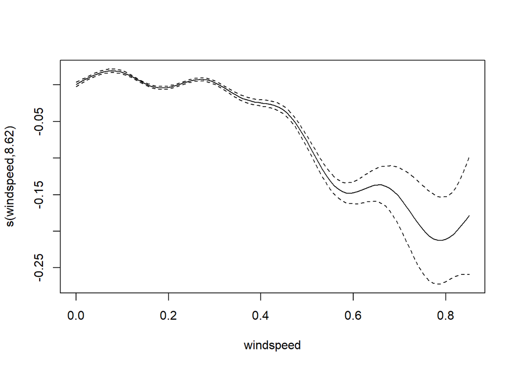

```r
bik.gam=gam(cnt~s(windspeed)+season+yr+mnth+hr+holiday+weekday+weathersit,family=poisson,data=bik.df)


plot(bik.gam, residuals=F,pages = 1,pch=20)
```

#### Q2 (c)

3. [3 marks] Fit a Poisson regression model using all columns except cnt to try to predict cnt. Add a quadratic term for windspeed.

```r
bik.pois=glm(cnt~I(windspeed^2)+windspeed+season+yr+mnth+hr+holiday+weekday+weathersit,family = poisson,data=bik.df)
```

#### Q2 (d)

4. [6 marks] Produce the standard diagnostic plots and comment on each of them.

ANSWER:

- Residuals vs Fitted:

the line is a level straight line, it means the residualls are relatively constant.

Q-Q plot:

the line has non-linear signs,it is a slight curve line , whereas just shows a slightly non-linear sign. A quadratic term or interaction for explanatory varialbles can be considered to be added to the model.

Scale -location:

the line is trending up a little bit, it means the residuals slightly widen over X. Absolute pearson residuals are slightly non-constant.

Cook’s distance:

points 8855, 586,4316 has high cook distances ,would have potential high influential. but their cook distance all less then 0.5, within reasonable range.

Residuals vs Leverage:

8855 points on the contour line of Cook’s distance of 0.5, shold be caught attention for high leverage potential. 8855 and 586 have very less residual,hence, 586 and 8866 won’t have much influence, though 8855 is in the area of “potential high leverage”. 4316 has relatively high residual against 8855 and 586, corespondingly it has low leverage.

Cook’s dis vs Leverage* hii/(1-hii):

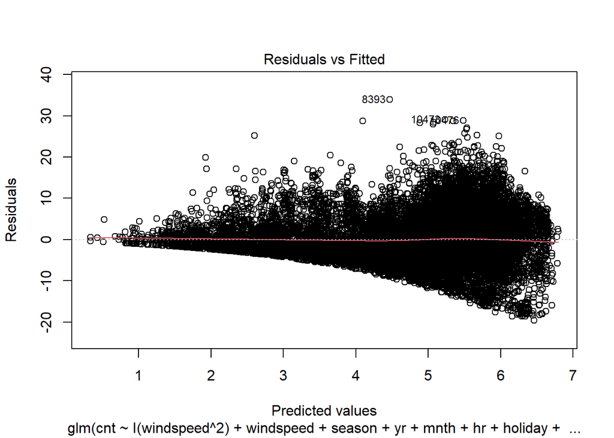

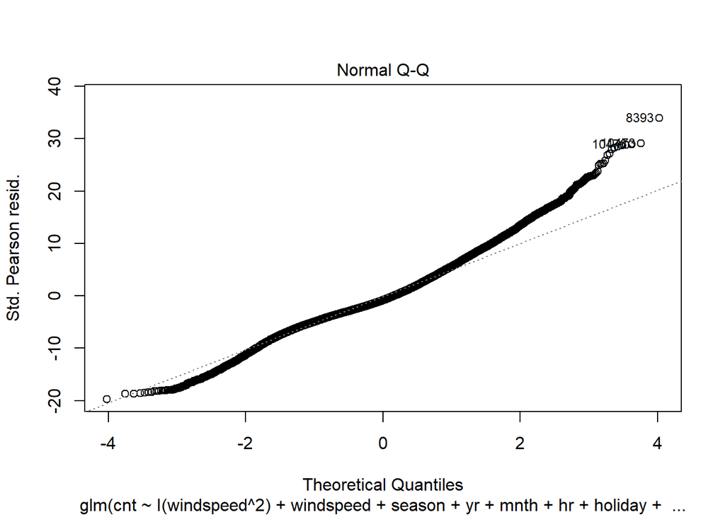

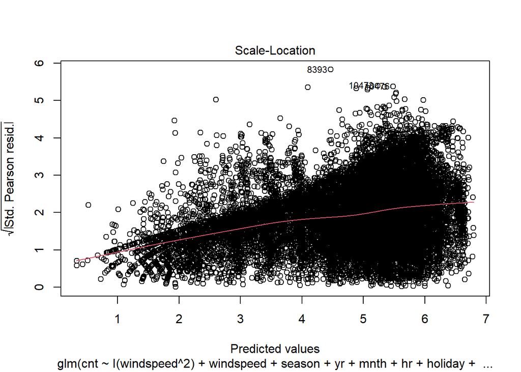

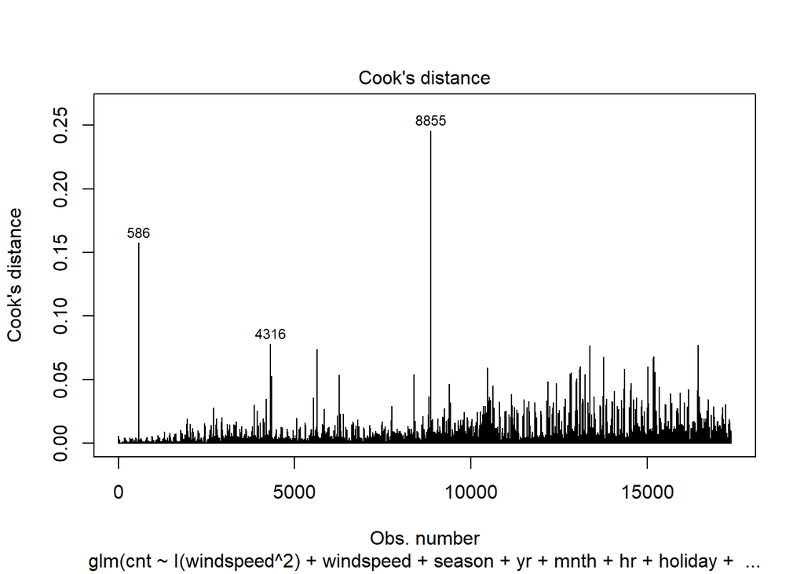

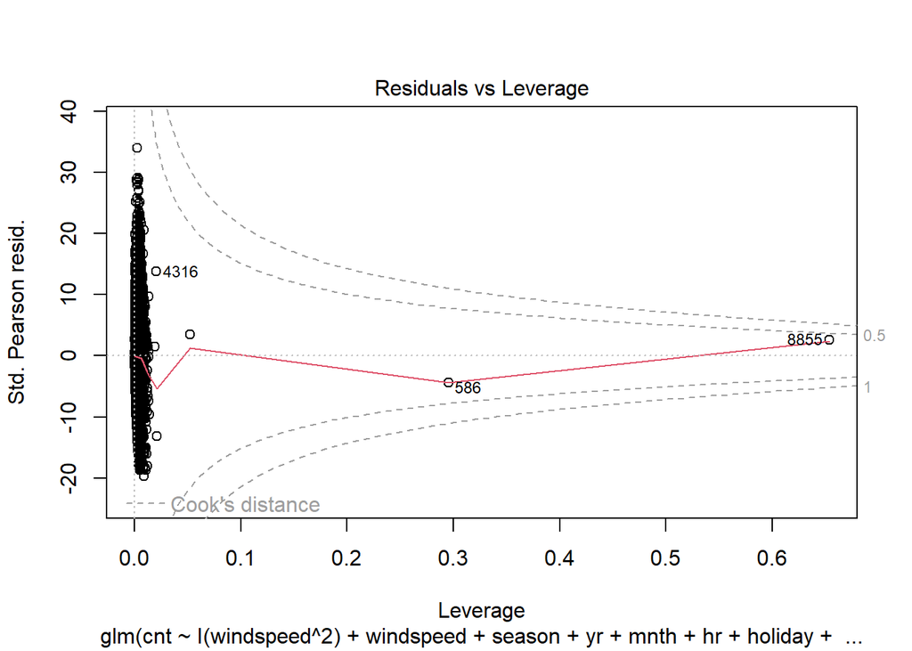

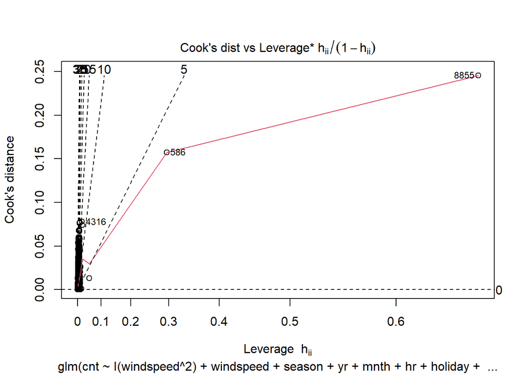

```r
plot(bik.pois,which=1:6)
```

#### Q2 (e)

5. [3 marks] Repeat parts (c) and (d) with a negative binomial model, and identify which model is preferred using the AIC values, the residual deviance, and the diagnostic plots.

ANSWER:

- Residuals vs Fitted:

The line is quite level and straight, hence, the residuals are constant which is similar with poisson diagnostic plot.

- Q-Q plot:

- Scale location:

The line is a little bit trending down , which shows different trending sighs with that of possion model. It means the absolute residuals narrows over x-axis.  
Whereas in poisson model, the line in this plot is trending up.

- Cook’s distance:

9124 and 6301 , 586 have highest cook’s distance which all are less than 0.5 and 1. It means these points should have potential of high leverage. 9124 and 6301 points are different with what we got from poisson model.

- Residuals vs Leverage:

6301 has highest residual against 9124 and 586 points, moreover, 6301 has quite high Cook’s distance , but 6301 has low x value, hence 6301 has medium leverage. 586 has high leverage though 586’s residual is low, since its x-value is high.. 9124 has high leverage though its residual is low, since its x-value is higt.

- Cook’s dist vs Leverage* hii/(1-hii):

Which model is preferred?

negative binomial is preferred. The reason is as below:

- Residual deviance:

for poisson is:597499 , whereas for negative binomial is: 18571, 18571 is much less than 597499. Hence, negative binomial model is preferred in terms of reducing the residual deviance, closer to max. model.

- Diagnostic plot:

in Scale location plot , the lines for negative binomial model is relatively level , it shows a good signs of constant variance for residuals. Whereas the lines in poisson model is trending up, it means the variance of absolute residual is increasing, it is not a good signs for a goodness of model. Other plots showed not significant signs of differet of two models.

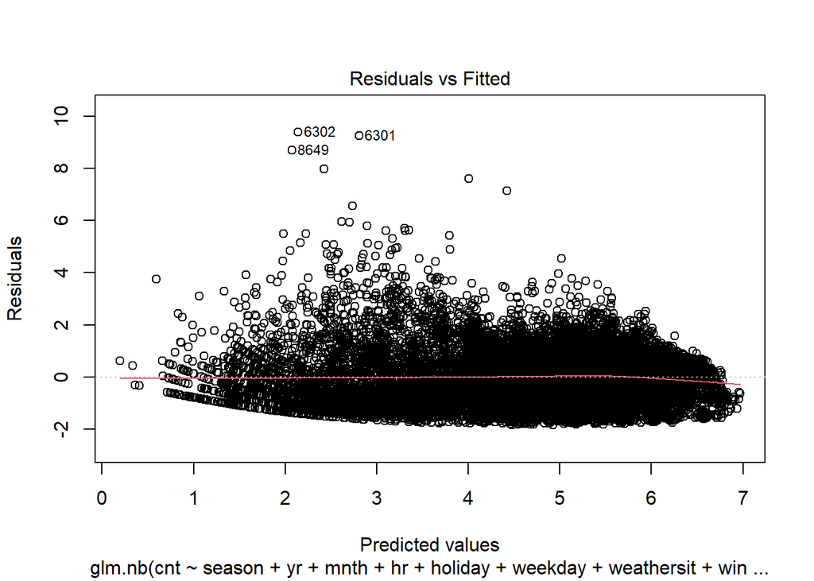

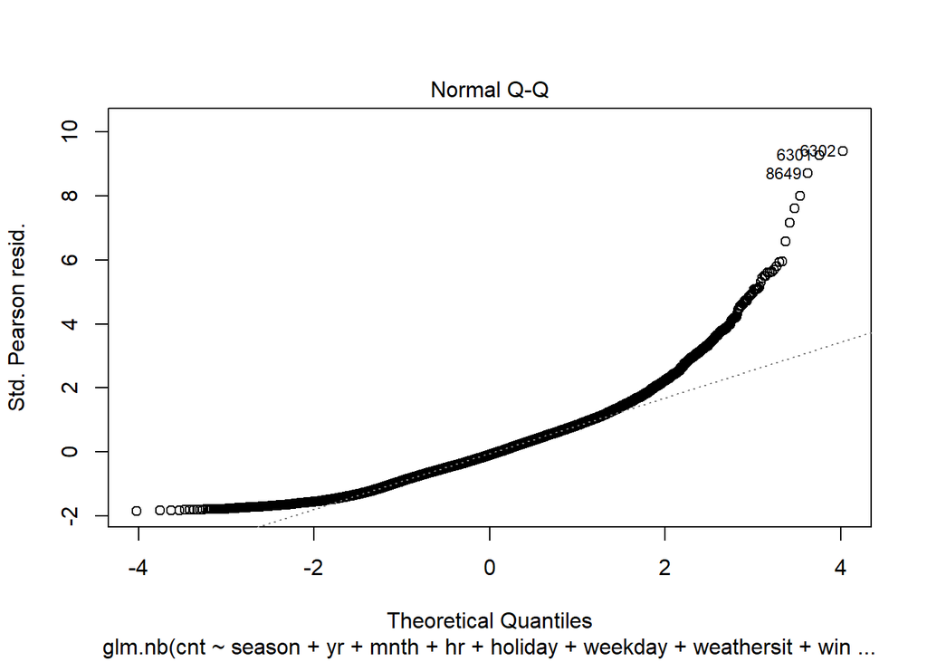

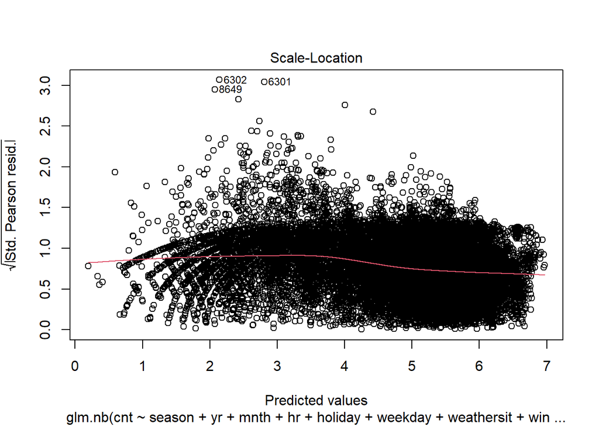

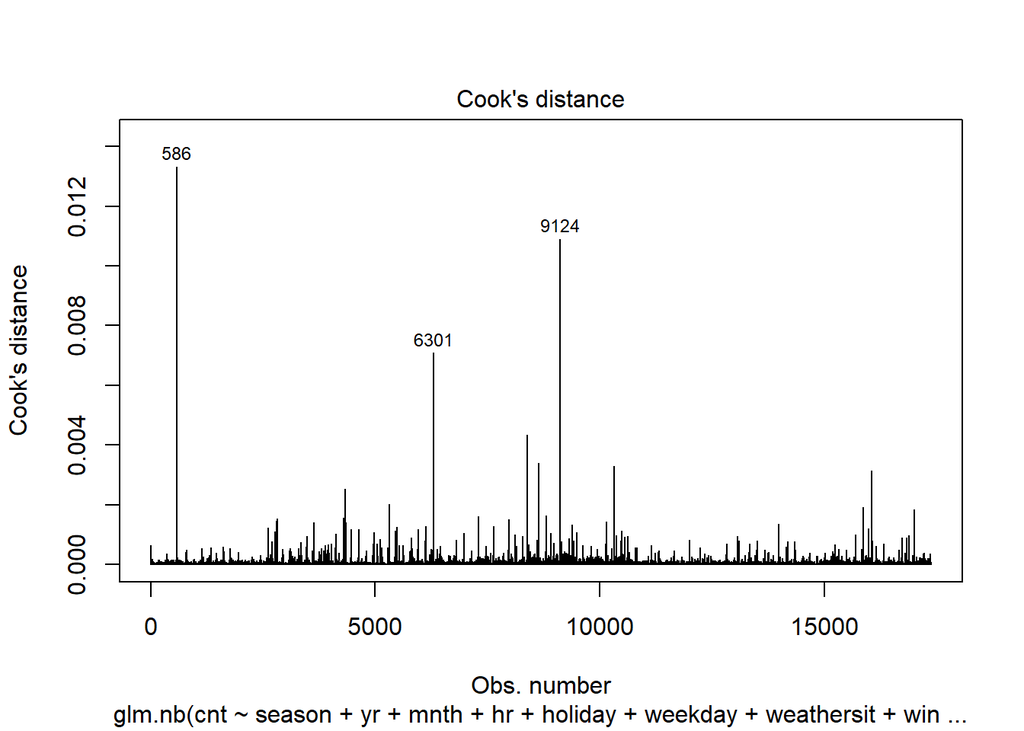

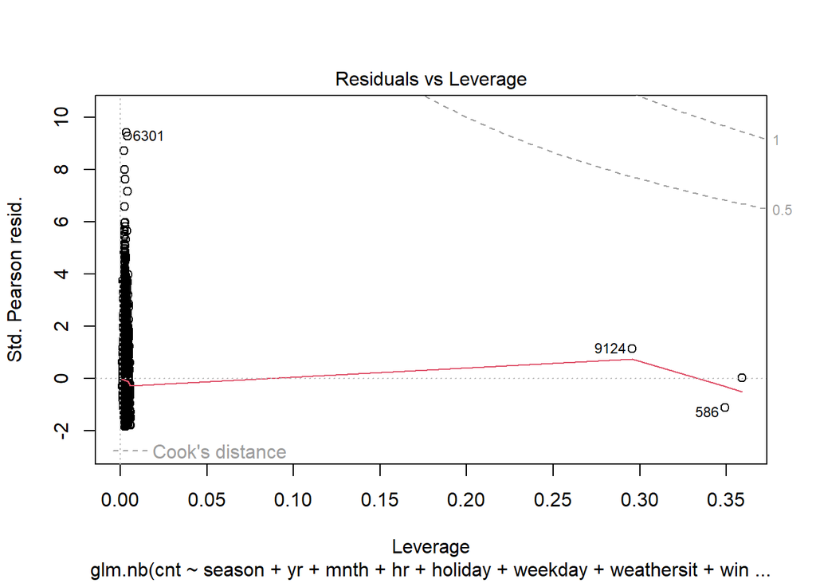

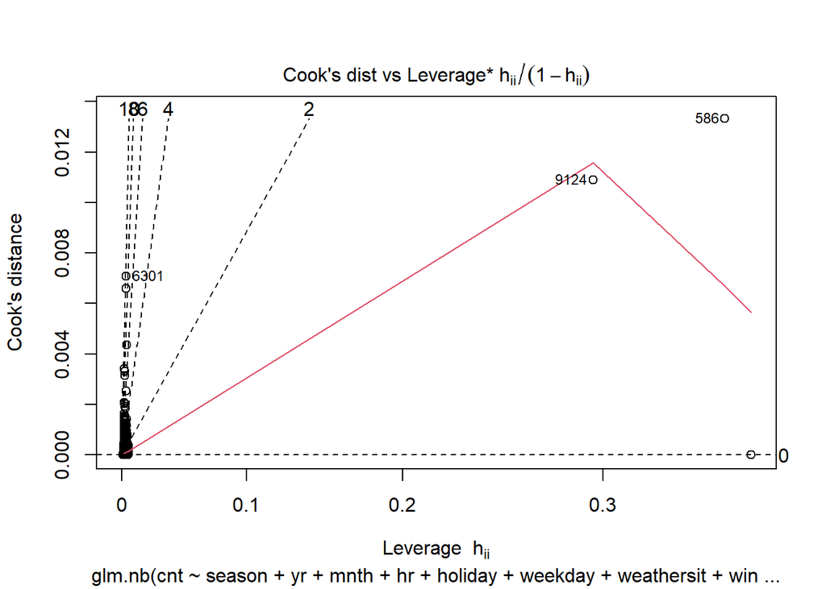

```r
bik.nb=glm.nb(cnt~season+yr+mnth+hr+holiday+weekday+weathersit+windspeed+I(windspeed),data=bik.df)
# summary(bik.nb)

plot(bik.nb,which=1:6)
```

6. [3 marks] Does the preferred model pass a goodness of fit test?

ANSWER:

p-value for chisq test is: 3.469536e-11, very small, hence,null hypothesis is rejected: it has strong evidence that this model lacks of fit.

Negative binomial model in this case can’t pass goodness of fit test

```r
# implement goodness of fit test using chisq test

1-pchisq(18571,17329)
```

```
## [1] 3.469536e-11
```

### Question 3 [10 marks]

#### (a) [4 marks] Use dredge() to find the model

with the lowest AIC, starting with your preferred model from Question 2. Compare the AIC value of the best model to the one that includes all terms.

ANSWER:

AIC for the best model is: 189014, slightly be improved agaist the AIC in Q2 which is: 189015, Hence, the best model is preferred due to smaller AIC.

```r
# install.packages("MuMIn")
library(MuMIn)

options(na.action = "na.fail")
all.fits=dredge(bik.nb)
```

```
## Fixed term is "(Intercept)"
```

```r
best.model=get.models(all.fits,1)[[1]]
summary(best.model)
```

```
##
## Call:
## glm.nb(formula = cnt ~ hr + mnth + season + weathersit + weekday +
##     windspeed + yr + 1, data = bik.df, init.theta = 3.563139159,
##     link = log)
##
## Deviance Residuals:
##     Min       1Q   Median       3Q      Max
## -4.6367  -0.7283  -0.0943   0.4909   4.7505
##
## Coefficients:
##              Estimate Std. Error z value Pr(>|z|)
## (Intercept)  3.090741   0.028046 110.204  < 2e-16 ***
## hr1         -0.481935   0.029311 -16.442  < 2e-16 ***
## hr2         -0.858717   0.029790 -28.826  < 2e-16 ***
## hr3         -1.522931   0.031090 -48.984  < 2e-16 ***
## hr4         -2.105551   0.032774 -64.244  < 2e-16 ***
## hr5         -0.928507   0.029854 -31.101  < 2e-16 ***
## hr6          0.438941   0.028767  15.258  < 2e-16 ***
## hr7          1.472244   0.028516  51.628  < 2e-16 ***
## hr8          2.025587   0.028464  71.162  < 2e-16 ***
## hr9          1.516353   0.028535  53.140  < 2e-16 ***
## hr10         1.208689   0.028593  42.272  < 2e-16 ***
## hr11         1.378422   0.028577  48.236  < 2e-16 ***
## hr12         1.592940   0.028559  55.777  < 2e-16 ***
## hr13         1.597705   0.028559  55.944  < 2e-16 ***
## hr14         1.548051   0.028595  54.137  < 2e-16 ***
## hr15         1.595928   0.028597  55.807  < 2e-16 ***
## hr16         1.819089   0.028577  63.656  < 2e-16 ***
## hr17         2.240494   0.028530  78.532  < 2e-16 ***
## hr18         2.155211   0.028528  75.547  < 2e-16 ***
## hr19         1.819789   0.028514  63.821  < 2e-16 ***
## hr20         1.492453   0.028528  52.315  < 2e-16 ***
## hr21         1.214486   0.028547  42.544  < 2e-16 ***
## hr22         0.936717   0.028596  32.757  < 2e-16 ***
## hr23         0.529440   0.028709  18.442  < 2e-16 ***
## mnth2        0.184904   0.021196   8.723  < 2e-16 ***
## mnth3        0.368247   0.022670  16.244  < 2e-16 ***
## mnth4        0.442442   0.033405  13.245  < 2e-16 ***
## mnth5        0.693789   0.033215  20.888  < 2e-16 ***
```

[output cut: 22 more lines]

```
## Signif. codes:  0 '***' 0.001 '**' 0.01 '*' 0.05 '.' 0.1 ' ' 1
##
## (Dispersion parameter for Negative Binomial(3.5631) family taken to be 1)
##
##     Null deviance: 81249  on 17378  degrees of freedom
## Residual deviance: 18570  on 17330  degrees of freedom
## AIC: 189014
##
## Number of Fisher Scoring iterations: 1
##
##
##               Theta:  3.5631
##           Std. Err.:  0.0404
##
##  2 x log-likelihood:  -188913.5550
```

#### Q3 (b) [6 marks] Using the estimated coefficients

from the best model in (a), tell a story about when, and under what conditions, more people use the bike share system.

ANSWER:

- For the best model,

- mnth

all of mnth has positive coef, it means the bike rental would increase if the coef of mnth increases. From 6 to 8 ( Jun to August) in mid year have the most higt level positive influence on bike rental , since 6, 7 and 8 (Jun, July , August ) has the 3 highest coefs within mnth group. In this 3 months ,the bike rental would be increased mostly.

- season

All the coefs for season is positive which means the season has positive impact on the bike rental. seaon 4 is winter . From the coef. comparison, winter would increase the bike rental more than the other summer and fall. As season 1 is spring which is included in Intercept. The coef of winter shows the positive signs that season 4 (winter) would increase bike rental mostly comparing with other seasons.

- weathersit

coefs of weathersit (2,3,4) is negative, it means 2-4 weathersit would decrease the bike rental.

Weathersit 1 is included in Intercept, hence the weather 1 ( clear) Clear weather would increase the bike rental comparing with other weather.

- weekday

Coefs for weekday 1 to weekday 5 ( weekdays) are all negative which means busy working weekday would decrease the bike rental. weekday0 (Sunday) would have positive impact on the bike rental. The weekday6 has positive coef (coef 0.02) but no significant. Hence, generally speaking, weekday0 ( Sunday) would increase the bike rental.

- windspeed

coef of windspeed is negative, bear them in mind that windspeed is not a factor, as a result , the windspeed increases 0.12, the bike rental would decrease by 0.12 * a unit of bike rental.

- yr1

yr1 is 2012, 2012 have positive impact on the bike rental. Hence, yr1 (2012) would increase the bike rental more than yr0 (2011).